# Unit 6

# Goals

- Percentile
- Boxplot
- Data visualization exercises

# Previously

We have learned how to use

1. Table
2. Pivot table
3. Bar plot
4. Overlaying histogram
5. Multi-faceted histogram

These are really awesome forms of data visualization. We will look at boxplot this time and look pros and cons of each method. Boxplot itself relies on other summary statistics: percentile.

# Percentile

Remember the 99% movement couple years ago? It is actually statistically-motivated.

If you are at 99th percentile of the income distribution, then you are relatively very rich. You earn more than 99% of the people (and only 1% of the people earn more than you.).

If we do not want the income disparity to be too severe, we want the relatively rich people (e.g. 99th percentile) to not be too rich.

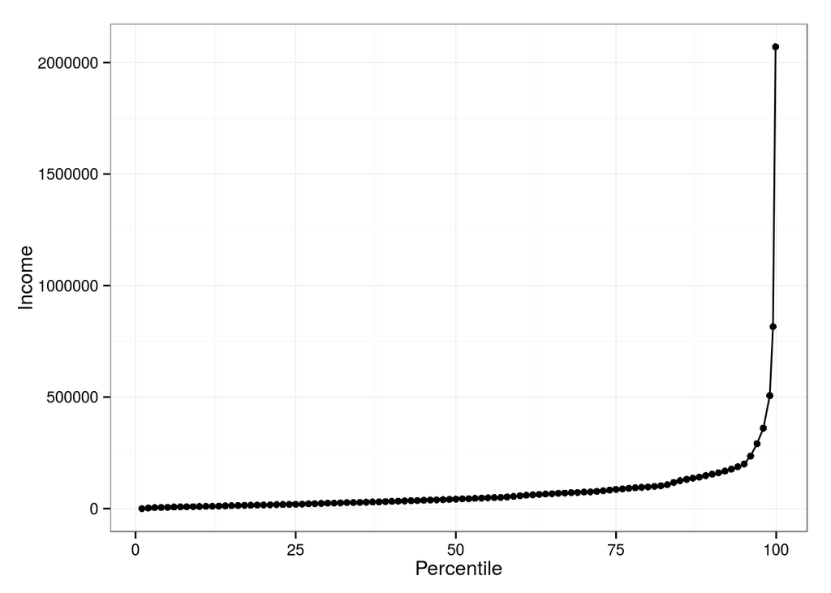

Wow the relatively rich people have a lot of money. But let’s discard the insane rich people and look at the bottom 80%.

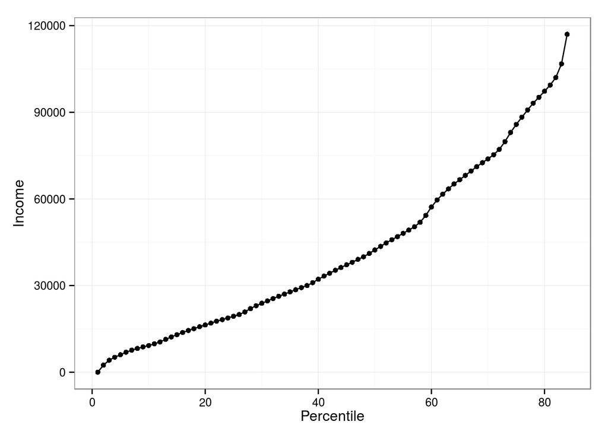

The middle class people earn reasonably well.

50th percentile earns 42k

60th percentile earns 57k

But the upper middle class earn much much more.

70th percentile earns 73k

80th percentile earns 97k

## Definition

The values of the $n$th percentile of the data are the values that are greater than $n$% of the data.

If your height is at 80th percentile, then you are taller than 80% of the people. If sort people by height, 80% of the people will be on your left.

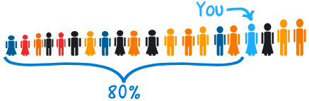

# Boxplot

Histograms can be pretty messy and too fine-grained because they show so many things i.e. the count of data in each bin in each group.

And summary statistics can be too coarse because they leave out too much information. Boxplot is something in the middle. And this is sometimes what we want.

# What is shown in a boxplot?

There is a variation for what a boxplot shows. Traditionally, a boxplot shows six things:

1. Top whisker - some extreme high value. (we will not talk about the detail)
2. Top of the box - 75% percentile
3. Middle of the box - 50% percentile (median)
4. Bottom of the box - 25% percentile
5. Bottom whisker - some extreme low value. (we will not talk about the detail)
6. Dots - Beyond extreme values.

To carry on the UI study example from last unit, a boxplot might look like this.

For just age grouping variable,

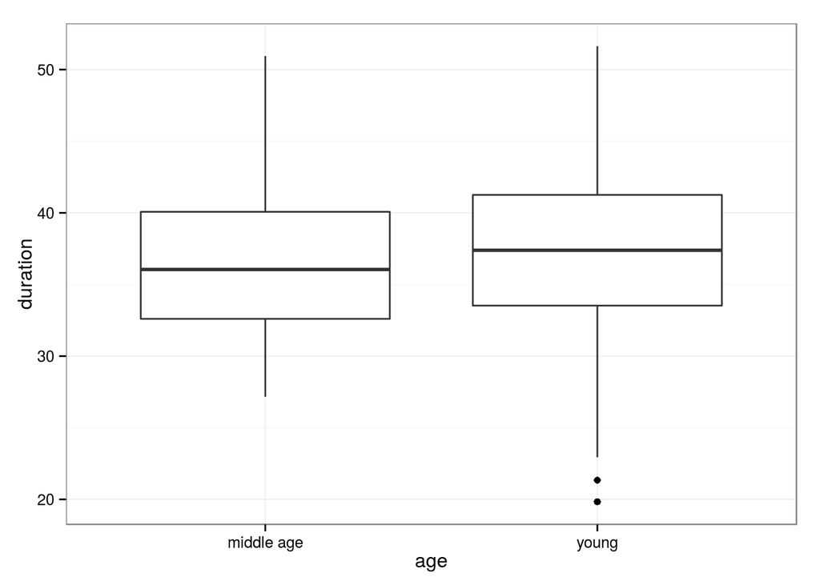

```r
d = read.csv('../datasets/ui_study.csv')
library(ggplot2)
ggplot(aes(x=age, y=duration),data=d) + geom_boxplot() + theme_bw()
```

For all interactions,

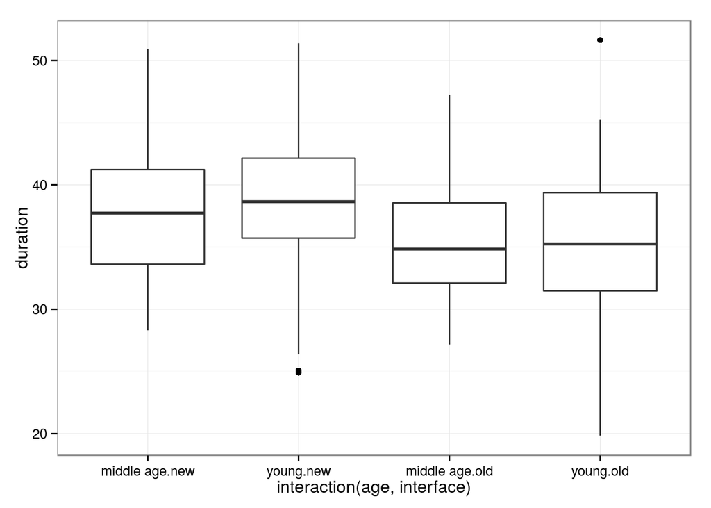

```r
ggplot(aes(x=interaction(age,interface), y=duration),data=d) + geom_boxplot() + theme_bw()
```

Questions

- What would a boxplot look like if the variance is low?
- If there are many extreme values, what would a boxplot look like?
- What’s the disadvantage of boxplots compared to histogram?